# Introduction to Research Methods

Stijn Masschelein

February, 2018

# 1 Research Methods in Finance and Accounting

## 1.1 Introduction

- Preparation to do empirical research (in accounting and finance)
- From theory to data
- From data to statistical tests

The emphasis on the units will be on the practical and statistical issues of the data analysis part of a thesis. The influence will not be on the accounting and finance part of your thesis. The goal is to be relevant to everyone in the unit.

## 1.2 Four Modules

1. The research process and basic data skills by me
2. Timeseries and databases by Prof. Dirk Bauer
3. Panel data and identification by Prof. Jing Yang
4. Restricted dependent variable and survey data by Prof. Paul Gerrans

All modules work as stand-alone 3-week units and aim to cover a wide range of topics. Not all of them will in the end be relevant for everyone. However, it is probably a good idea to get to know the different statistical methods, their advantages, and disadvantages. Bringing a new methodology to an old topic can be a valuable contribution. Some problems have already been solved in other research streams.

## 1.3 Assessment

- No Exam
- Four assignments (%)
- Proposal and presentation (%)

We want you to (1) do some data analysis and (2) be well prepared to undertake (the data analaysis part of) a research project. So we are going to evaluate you by letting you (1) analyse data and (2) prepare your honours thesis.

# 2 The first three weeks: CEO compensation

## 2.1 Warning: I am not a specialist

[figure not shown]

I am not a specialist in the topic nor in this type of data analysis. CEO compensation is something that people in finance, accounting, economics, and outside of academia are interested in. The topic is probably the one with the most commonality. I am comforable with these type of economic theories and I am going to stress the role of theory in data analysis a lot. Some of you will have a topic that is at first sight less theory driven or rely more strongly on very specific knowledge about your setting. I am going to try to convince you that it is going to be useful to think about the underlying story that you are testing.

## 2.2 Topic

Completely based on [“Executive Compensation: A Modern Primer”](https://dx.doi.org/10.1257/jel.20161153) by Alex Edmans and Xavier Gabraix in *Journal of Economic Literature*.

- The level of CEO compensation
- CEO incentives

I am going to focus on two topics.

## 2.3 Theory

### 2.3.1 Firm production function

$$V = T^{\alpha_T} \Bigl( \frac{K}{\alpha_K} \Bigl)^{\alpha_K}
\Bigl( \frac{L}{\alpha_L} \Bigl)^{\alpha_L}
\\
\alpha_T + \alpha_K + \alpha_L = 1$$

- $V =$ The value of the firm
- $K =$ Capital of the firm
- $L =$ Labour of the firm
- $T =$ CEO talent/skills/ability/experience

We assume that there is nothing in the structure of the production function that favours a particular firm size, i.e. constant returns to scale ($\alpha_T + \alpha_K + \alpha_L = 1$).

### 2.3.2 CEO decision

$$W_T = \max_{K, L} V - w_L L - rK$$

The CEO maximises their income $W_T$ by attracting capital at a cost, $r$, and and hiring labour at a wage, $w_L$. The model assumes that the CEO takes the ultimate decision. As it turns out when you assume competitive labour and financial markets, that assumptions does not really matter a lot.

This model is too simple to capture reality perfectly. However, that is not the goal of the model and of this exercise. The idea is to see whether we can find a reasonable baseline for CEO compensation that we can test against the data.

## 2.4 Relation between size and CEO wage

$$W_T = \alpha_T V$$

> In this model, the driving force is that more talented CEOs grow the business to a bigger size and they earn more money when they create more value.

First find the optimal level of capital …
$$\frac{\partial V}{\partial K} = T^{\alpha_T}
\Bigl( \frac{K}{\alpha_K} \Bigl)^{\alpha_K - 1}
\Bigl( \frac{L}{\alpha_L} \Bigl)^{\alpha_L} - r = 0
\\
T^{\alpha_T} \Bigl( \frac{K}{\alpha_K} \Bigl)^{\alpha_K}
\Bigl( \frac{L}{\alpha_L} \Bigl)^{\alpha_L}
\frac{\alpha_K}{K}
= r
\\
\frac{V}{r} = \frac{K}{\alpha_K}$$
… and labour
$$\frac{\partial V}{\partial K} = T^{\alpha_T}
\Bigl( \frac{K}{\alpha_K} \Bigl)^{\alpha_K}
\Bigl( \frac{L}{\alpha_L} \Bigl)^{\alpha_L - 1} - w_L
\\
T^{\alpha_T} \Bigl( \frac{K}{\alpha_K} \Bigl)^{\alpha_K}
\Bigl( \frac{L}{\alpha_L} \Bigl)^{\alpha_L}
\frac{\alpha_L}{L} = w_L
\\
\frac{V}{w_L} = \frac{L}{\alpha_L}$$

Now we can plugin $L$ and $K$ in $V$ …

$$V = T^{\alpha_T} \Bigl( \frac{V}{r} \Bigl) ^{\alpha_K}
\Bigl( \frac{V}{w_L} \Bigl) ^{\alpha_L}
\\
V^{1 - \alpha_K - \alpha_L} = \frac{T^{\alpha_T}}
{r^{\alpha_K} w_L^{\alpha_L}}
\\
V^{\alpha_T} = \frac{T^{\alpha_T}}
{r^{\alpha_K} w_L^{\alpha_L}}
\\
V = \frac{T}
{r^{\frac{\alpha_K}{\alpha_T}} w_L^{\frac{\alpha_L}{\alpha_T}}}$$

… and in $W_T$.

$$W_T = V - V \alpha_K - V\alpha_L = (1 - \alpha_K - \alpha_L) V = \alpha_T V$$

I like the basic intuition and deriviation of the model. The derivation is straightforward and (some of) the implicit assumptions are relatively easy to accept. The effect of the CEO depends on the size of the firm ($V$). When there is more capital and labour available a more talented CEO will have a bigger impact. The model also predicts a clear quantitative relationship between firm size, $V$, and CEO compensation, $W_T$, i.e. that relationship should be linear. This is a nice result that we can test with data. In contrast to the linear relationship between firm size and CEO talent. We can measure $V$ but not $T$.

## 2.5 Data: Relation Compensation-Value

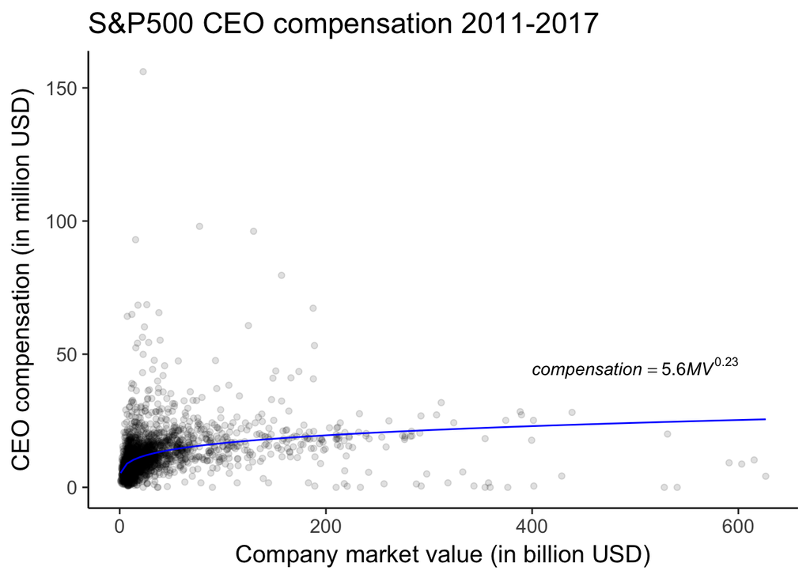

```r
# Read the data from a custom folder. If the data is not in this folder, change
# the path to the folder. Rename some of the variables to make them easier to
# work with.
folder = "~/Dropbox/R/wrds/data/"
us_comp = readRDS(paste0(folder, "us-compensation.RDS")) %>%
  rename(total_comp = tdc1)
us_value = readRDS(paste0(folder, "us-value.RDS")) %>%
  rename(year = fyear, market_value = mkvalt) %>%
  distinct
# Match the compensation data with the value data based on company key and year
us_comp_value = left_join(select(us_comp, gvkey, year, total_comp),
                          us_value, by = c("year", "gvkey"))
# Run the non-linear regression and save the results as an equation to put on
# the figure. This goes beyond what we are going to do in this module.
power_law_start = list(a= 5, b = .15)
power_law_comp = nls(total_comp/1000 ~ a * (market_value/1000)^b,
                     data = us_comp_value, start = power_law_start)
eqn_comp = substitute(italic("compensation") == a * italic("MV") ^ b,
                      list(a = format(coef(power_law_comp)[1], digits = 2),
                           b = format(coef(power_law_comp)[2], digits = 2)))
# create the plot
plot_comp_value =
  # Add dataset and define x and y axis
  ggplot(us_comp_value, aes(x = market_value/1000, y = total_comp/1000)) +
  # Add the observations as points to the plot
  geom_point(alpha = .125) +
  # Draw the results of the power_law regression on the plot
  stat_function(fun =
                function(x){
                  coef(power_law_comp)[1] * x ^ coef(power_law_comp)[2]},
                colour = "blue") +
  # Add a title
  ggtitle("S&P500 CEO compensation 2011-2017") +
  # Add label for the x-axis and y-axis
  ylab("CEO compensation (in million USD)") +
  xlab("Company market value (in billion USD)")
```

The data is downloaded from Compustat and Execucomp. A lot of you will use these are similar databases in your research project. I did not clean or check the data for this exercise. In your own project, you should show a better understanding of how the data are gathered and what they include than what I am displaying here.

- CEO compensation is fairly complete. It includes changes in the value of equity and options.
- Market value also includes all outstanding financial instruments on the company.

The qualitative relationship holds quite well. Bigger companies have CEOs with higher compensation. However, the relationship is far from linear and looks more like a power function. Clearly there are other effects at play. In this sample, the power coefficient is 0.23. Prior studies have found a coefficient more closely to 0.33 (Baker, Jensen, and Murphy 1988). Remember that in our setup the CEO can grow the firm at will by attracting more capital and more labour. That assumption is probably too strong.

## 2.6 The research process

- Make assumptions
- Derive relationship between measurable quantities
- Compare the theory and the data

Note what we have just done. We started with some assumptions about the production function of a company and competitive markets to find the theoretical relation between firm size and CEO compensation. We followed up by testing this theory to data from S&P500 firms. These are the steps that you should be following.

# 3 Details of the research process

## 3.1 Literature search

- https://www.scholar.google.com
- https://onesearch.library.uwa.edu.au
- https://apps.webofknowledge.com
- [EBSCOhost Research Databases](https://search.ebscohost.com/login.asp?defaultdb=bth&lang=en)
- https://ssrn.com/en/
- https://www.nber.org/papers.html

In most cases (ssrn is the exception), you will have to be on the university’s network if you want to actually read the full paper.

- Google Scholar is probably the most comprehensive repository. This search engine work very similar to regular Google search. There are some additional tricks you can use “author:lastname-firstname” will help you to narrow down papers from a specific author. “intitle:keyword” let’s you search for keywords in the title of papers. You can also narrow down your search based on year of publication. The advanced search features hidden in the left side bar give you additional options such as searching for certain journals. If you are on the university network, Google Scholar will tell you for every paper whether it is accessible or not.
- Onesearch is the university search engine. It’s the best way to figure out whether there is an easily accessible version of the paper.
- Webofknowledge and EBSCOhost are two publisher driven initiatives. They work pretty well. Each with their own quirks.
- SSRN (Social Science Research Network) and NBER (National Bureau of Economic Research) both provide access to their own not-yet-peer-reviewed paper repositories. Here you go to find cutting edge research.

## 3.2 Start of literature search

- Don’t start too narrow!
- Review(s) articles and journals
  - Journal of Economic Literature
  - Journal of Accounting Literature
- A*/A journals
  - [Accounting](http://www.abdc.edu.au/master-journal-list.php?title=&issn=&for=3&rating=A*)
  - [Finance](http://www.abdc.edu.au/master-journal-list.php?title=&issn=&for=4&rating=A*)

My favourite way to start a research project now is to find one or two excellent overview or review papers. A (systematic) review paper provides a state of a research field and identifies interesting new research questions. I am not sure whether my strategy will work for you. I find that a good review paper gives a good list of papers you can build on and they often already compare the most important papers in a field. The trick is to be not too picky. You probably will not find a review for your exact reserch problem but it is unlikely that you will not find a partly relevant overview paper. You can search for review papers by adding “intitle:review” or “intitle:overview” to your Google Scholar search.

To find other papers relevant to your topic, you can build on the review paper by (1) looking up the papers referred to in the review paper and (2) search for papers that cite the review paper. You can do the latter via Google Scholar and Webofknowledge.

To find good reviews, I think you should start your search in the better journals. Some journals are dedicated to these literature reviews for instance *Journal of Economic Literature* and *Journal of Accounting Literature*. I am not aware of a similar journal in finance but I will happily add it if you let me know.

When you start your literature search, you don’t want to narrow. You are not going to find an overview paper about “CEO compensation in Australian mining companies after the GFC”. However, you can start with an overview paper about CEO compensation. Like the one I found: [“Executive Compensation: A Modern Primer”](https://dx.doi.org/10.1257/jel.20161153) by Alex Edmans and Xavier Gabraix in *Journal of Economic Literature*.

## 3.3 Data analysis tools

- [Install R](https://cran.curtin.edu.au/)
- [Install Rstudio](https://www.rstudio.com/products/rstudio/download/#download)
- [RMarkdown](http://rmarkdown.rstudio.com/authoring_basics.html)
- [R for datascience](http://r4ds.had.co.nz/)

> I will help you with any questions about these tools during your honours year. We will only scratch the surface in the first three weeks.
- R is free software specifically aimed at statistical analysis and graphical representation. It is a fully developed programming language that allows to extend it with new packages with new capabilities. We are going to heavily rely on some of those packages. You can save the different steps in your analysis in an R script which is just a plain text file with the “.R”-extenstion.
- Rstudio is an integrated development environment for R. It allows you to easily write, test, and run R code, and integrate the results with explanations. One advantage of R and Rstudio is that you can install them on as many computers as you want. You do not need a special license.
- RMarkdown is an R extension of the markdown format. The idea of markdown is to write plain text documents which can later be exported to other formats such as html, pdf, or word. The advantage of plain text scripts and markdown. The beauty of RMarkdown is that it lets you combine both R scripts and markdown into one document. These slides and lecturenotes are generated from one underlying document. I will not be asking you to anything like that but it does illustrate the power of the RMarkdown approach.
- Finally, I am going to introduce you to a specific dialect of the R language which is informally known as the tidyverse. You will see later why. If you want to be a good R programmer this might not be the best entry point into R. However, I assume that you want to quickly pick up some tools to facilitate your research project and for that purpose I believe the tidyverse will be excellent. I will introduce the most important bits and pieces throughout my lectures however I don’t have the time to go into detail. Now and then, you will have to experiment on your own a get your code working. An excellent resource is the free online book “R for datascience”. You can also buy reasonably priced physical copies if you your are interested in developing your R skills further.

## 3.4 The R console

```r
x = 1
x
```

```
## [1] 1
```

```r
x = x + 1
x
```

```
## [1] 2
```

You can directly type your R code in the console. The little code above already shows you two things.

- You can assign (and overwrite) a numerical value to an object `x`
- The right-hand side is assigned to the left-hand side. You can’t just switch them around.

## 3.5 R packages

```r
install.packages("tidyverse")
install.packages("ggplot2")
library("tidyverse")
library("ggplot2")
```

We will heavily rely on two packages. `tidyverse` is a package that helps with data transformations and working with tabular data in a tidy fashion. `ggplot2` provides tools to make pretty plots.

The code also gives you an idea how to install packages and use them. Normally, you will only have to install a package once. However, when you want to use a package in your script or code, you will have to load the package with the `library()` function. You only have to do load a package once at the start of your R session or at the start of your script.

I would advise you to use the console for only two purposes.

1. To test your script by running part of your code or showing intermediate values to check whether your code is doing what you think it should be doing.
2. To install packages and do R(Studio) maintenance.

For real work, you are better off writing an R script and running that script in RStudio. Further on, I will show you how to do that.

## 3.6 The dplyr verbs to explore and transform data.

- `filter()`
- `select()`
- `mutate()`
- `group_by()` and `summarise()`
- `%>%`

These functions will be your main tools to filter observations in your data, select different variables, mutate variables, group observations and summarise the variables in the groups. The pype operator, `%>%`, lets you glue these different verbs together.

## 3.7 Looking for help

- Trial and error
- Google
- StackExchange
- Help window in RStudio
- R for Data Science
- LMS

# 4 A first script

## 4.1 Project management in RStudio

- Change “Restore .Rdata into workspace”-setting
  - `Tools > Global Settings ...`
- Start a new project: `File > New Project ...`
- Start a new file: `File > New File > R Script`

[figure not shown]

## 4.2 Finally some useful code!

```r
library(tidyverse)
```

```r
us_comp = readRDS("~/Dropbox/R/wrds/data/us-compensation.RDS")
glimpse(us_comp)
```

```
## Observations: 2,973
## Variables: 17
## $ year                    <dbl> ...
## $ gvkey                   <chr> ...
## $ exec_fullname           <chr> ...
## $ coname                  <chr> ...
## $ ceoann                  <chr> ...
## $ execid                  <chr> ...
## $ bonus                   <dbl> ...
## $ salary                  <dbl> ...
## $ stock_awards_fv         <dbl> ...
## $ stock_unvest_val        <dbl> ...
## $ eip_unearn_num          <dbl> ...
## $ eip_unearn_val          <dbl> ...
## $ option_awards           <dbl> ...
## $ option_awards_blk_value <dbl> ...
## $ option_awards_num       <dbl> ...
## $ tdc1                    <dbl> ...
## $ tdc2                    <dbl> ...
```

## 4.3 A subset of the data.

```r
filter(us_comp, gvkey == "001045")
```

```
## # A tibble: 6 x 17
##    year gvkey  exec_fullname       coname       ceoann execid bonus salary
##   <dbl> <chr>  <chr>               <chr>        <chr>  <chr>  <dbl>  <dbl>
## 1  2011 001045 "Gerard J. Arpey  … "AMERICAN A… CEO    14591      0    614
## 2  2012 001045 "Thomas W. Horton … "AMERICAN A… CEO    26059      0    618
## 3  2013 001045 "Thomas W. Horton … "AMERICAN A… CEO    26059      0    592
## 4  2014 001045 "William Douglas P… "AMERICAN A… CEO    46191      0    688
## 5  2015 001045 "William Douglas P… "AMERICAN A… CEO    46191      0    232
## 6  2016 001045 "William Douglas P… "AMERICAN A… CEO    46191      0      0
## # ... with 9 more variables: stock_awards_fv <dbl>, stock_unvest_val
## #   <dbl>, eip_unearn_num <dbl>, eip_unearn_val <dbl>, option_awards
## #   <dbl>, option_awards_blk_value <dbl>, option_awards_num <dbl>, tdc1
## #   <dbl>, tdc2 <dbl>
```

## 4.4 CEOs with a salary over 1 million in 2014

```r
filter(us_comp, salary > 1000, year == 2014)
```

```
## # A tibble: 280 x 17
##     year gvkey  exec_fullname      coname       ceoann execid bonus salary
##    <dbl> <chr>  <chr>              <chr>        <chr>  <chr>  <dbl>  <dbl>
##  1  2014 001075 "Donald E. Brandt… "PINNACLE W… CEO    05835      0   1240
##  2  2014 001078 "Miles D. White  … "ABBOTT LAB… CEO    14300      0   1973
##  3  2014 001161 "Rory P. Read    … "ADVANCED M… CEO    42390      0   1000
##  4  2014 001300 "David M. Cote, J… "HONEYWELL … CEO    20931   5500   1866
##  5  2014 001380 "John B. Hess    … "HESS CORP … CEO    02132      0   1500
##  6  2014 001440 "Nicholas K. Akin… "AMERICAN E… CEO    40778      0   1241
##  7  2014 001447 "Kenneth I. Chena… "AMERICAN E… CEO    02157   4500   2000
##  8  2014 001449 "Daniel P. Amos  … "AFLAC INC … CEO    00013      0   1441
##  9  2014 001487 "Robert Herman Be… "AMERICAN I… CEO    20972      0   1385
## 10  2014 001598 "Frank S. Hermanc… "AMETEK INC… CEO    04252    520   1182
## # ... with 270 more rows, and 9 more variables: stock_awards_fv <dbl>,
## #   stock_unvest_val <dbl>, eip_unearn_num <dbl>, eip_unearn_val <dbl>,
## #   option_awards <dbl>, option_awards_blk_value <dbl>, option_awards_num
## #   <dbl>, tdc1 <dbl>, tdc2 <dbl>
```

## 4.5 Focus on some variables.

```r
select(us_comp, year, coname, bonus, salary, total = tdc1)
```

```
## # A tibble: 2,973 x 5
##     year coname                                         bonus salary total
##  * <dbl> <chr>                                          <dbl>  <dbl> <dbl>
##  1  2011 "AMERICAN AIRLINES GROUP INC                 …     0    614  5527
##  2  2012 "AMERICAN AIRLINES GROUP INC                 …     0    618   656
##  3  2013 "AMERICAN AIRLINES GROUP INC                 …     0    592 19093
##  4  2014 "AMERICAN AIRLINES GROUP INC                 …     0    688 12302
##  5  2015 "AMERICAN AIRLINES GROUP INC                 …     0    232 11419
##  6  2016 "AMERICAN AIRLINES GROUP INC                 …     0      0 11141
##  7  2011 "PINNACLE WEST CAPITAL CORP                  …     0   1091  6698
##  8  2012 "PINNACLE WEST CAPITAL CORP                  …     0   1146 10123
##  9  2013 "PINNACLE WEST CAPITAL CORP                  …     0   1203  7124
## 10  2014 "PINNACLE WEST CAPITAL CORP                  …     0   1240  7376
## # ... with 2,963 more rows
```

## 4.6 Homework

1. Turn script into RMarkdown file + make html
2. Find one relevant overview paper + we can have a talk.